# Chapter 02 Exercises

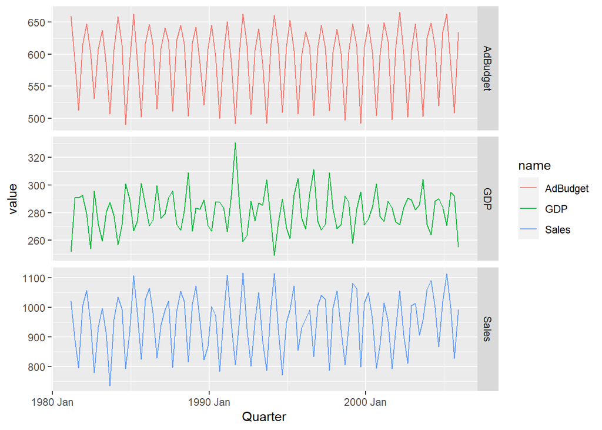

```r
my_timeseries %>%
  pivot_longer(-Quarter) %>%
  #autoplot
  ggplot(aes(x = Quarter, y = value, color = name)) +
  geom_line() +
  facet_grid(name ~ ., scales = 'free_y')
```

4. The `USgas` package contains data on the demand for natural gas in the US.
   1. Install the `USgas` package.
   2. Create a `tsibble()` from `us_total` with year as the index and state as the key.
   3. Plot the annual natural gas consumption by state for the New England area (comprising the states of Maine, Vermont, New Hampshire, Massachusetts, Connecticut and Rhode Island).

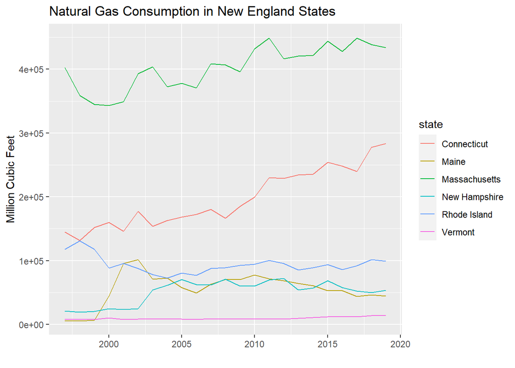

```r
gas_timeseries <- us_total %>%
  as_tsibble(key = state,
             index = year)

new_england <- c('Maine', 'Vermont', 'New Hampshire', 'Massachusetts', 'Connecticut', 'Rhode Island')

ne_gas <- gas_timeseries %>%
  filter(state %in% new_england)

autoplot(ne_gas, y) +
  labs(y = 'Million Cubic Feet',
       x = '',
       title = 'Natural Gas Consumption in New England States')
```

5. Download tourism.xlsx from the book website and read it into R using readxl::read_excel().
   1. Create a tsibble which is identical to the tourism tsibble from the tsibble package.
   2. Find what combination of Region and Purpose had the maximum number of overnight trips on average.
   3. Create a new tsibble which combines the Purposes and Regions, and just has total trips by State.

```r
tourism #original tourism tsibble
```

```
## # A tsibble: 24,320 x 5 [1Q]
## # Key:       Region, State, Purpose [304]
##    Quarter Region   State           Purpose  Trips
##      <qtr> <chr>    <chr>           <chr>    <dbl>
##  1 1998 Q1 Adelaide South Australia Business  135.
##  2 1998 Q2 Adelaide South Australia Business  110.
##  3 1998 Q3 Adelaide South Australia Business  166.
##  4 1998 Q4 Adelaide South Australia Business  127.
##  5 1999 Q1 Adelaide South Australia Business  137.
##  6 1999 Q2 Adelaide South Australia Business  200.
##  7 1999 Q3 Adelaide South Australia Business  169.
##  8 1999 Q4 Adelaide South Australia Business  134.
##  9 2000 Q1 Adelaide South Australia Business  154.
## 10 2000 Q2 Adelaide South Australia Business  169.
## # ... with 24,310 more rows
```

```r
# creating the tsibble to match tourism

fpp_tourism <- readxl::read_excel('tourism.xlsx')

fpp_tourism <- fpp_tourism %>%
  mutate(Quarter = yearquarter(Quarter)) %>%
  as_tsibble(key = c(Region, State, Purpose),
             index=Quarter)

fpp_tourism
```

```
## # A tsibble: 24,320 x 5 [1Q]
## # Key:       Region, State, Purpose [304]
##    Quarter Region   State           Purpose  Trips
##      <qtr> <chr>    <chr>           <chr>    <dbl>
##  1 1998 Q1 Adelaide South Australia Business  135.
##  2 1998 Q2 Adelaide South Australia Business  110.
##  3 1998 Q3 Adelaide South Australia Business  166.
##  4 1998 Q4 Adelaide South Australia Business  127.
##  5 1999 Q1 Adelaide South Australia Business  137.
##  6 1999 Q2 Adelaide South Australia Business  200.
##  7 1999 Q3 Adelaide South Australia Business  169.
##  8 1999 Q4 Adelaide South Australia Business  134.
##  9 2000 Q1 Adelaide South Australia Business  154.
## 10 2000 Q2 Adelaide South Australia Business  169.
## # ... with 24,310 more rows
```